# Scripts- Aula 04

Prof. Dr. Leandro Ferreira - profleandro.ferreira@fiap.com.br

2023-06-26

## Amostragem

#### Instalando e carregando os pacotes

```r
#install.packages("ggplot2")
library(ggplot2)
library(dplyr)
```

### Carregando a base imdb

```r
imdb <- readr::read_rds("imdb.rds")
```

### Explorando o data frame por linhas e colunas

```r
mtcars[1,10]
```

```
## [1] 4
```

```r
mtcars[2,  ]
```

```
##               mpg cyl disp  hp drat    wt  qsec vs am gear carb
## Mazda RX4 Wag  21   6  160 110  3.9 2.875 17.02  0  1    4    4
```

```r
mtcars[ , 3]
```

```
##  [1] 160.0 160.0 108.0 258.0 360.0 225.0 360.0 146.7 140.8 167.6 167.6 275.8
## [13] 275.8 275.8 472.0 460.0 440.0  78.7  75.7  71.1 120.1 318.0 304.0 350.0
## [25] 400.0  79.0 120.3  95.1 351.0 145.0 301.0 121.0
```

```r
mtcars[1:4, 2]
```

```
## [1] 6 6 4 6
```

```r
mtcars[ ,c(2, 10, 1)]
```

```
##                     cyl gear  mpg
## Mazda RX4             6    4 21.0
## Mazda RX4 Wag         6    4 21.0
## Datsun 710            4    4 22.8
## Hornet 4 Drive        6    3 21.4
## Hornet Sportabout     8    3 18.7
## Valiant               6    3 18.1
## Duster 360            8    3 14.3
## Merc 240D             4    4 24.4
## Merc 230              4    4 22.8
## Merc 280              6    4 19.2
## Merc 280C             6    4 17.8
## Merc 450SE            8    3 16.4
## Merc 450SL            8    3 17.3
## Merc 450SLC           8    3 15.2
## Cadillac Fleetwood    8    3 10.4
## Lincoln Continental   8    3 10.4
## Chrysler Imperial     8    3 14.7
## Fiat 128              4    4 32.4
## Honda Civic           4    4 30.4
## Toyota Corolla        4    4 33.9
## Toyota Corona         4    3 21.5
## Dodge Challenger      8    3 15.5
## AMC Javelin           8    3 15.2
## Camaro Z28            8    3 13.3
## Pontiac Firebird      8    3 19.2
## Fiat X1-9             4    4 27.3
## Porsche 914-2         4    5 26.0
## Lotus Europa          4    5 30.4
## Ford Pantera L        8    5 15.8
## Ferrari Dino          6    5 19.7
## Maserati Bora         8    5 15.0
## Volvo 142E            4    4 21.4
```

### Reproduzindo experimentos

```r
set.seed(1)
rnorm(5)
```

```
## [1] -0.6264538  0.1836433 -0.8356286  1.5952808  0.3295078
```

```r
rnorm(5)
```

```
## [1] -0.8204684  0.4874291  0.7383247  0.5757814 -0.3053884
```

```r
set.seed(1)
rnorm(5)
```

```
## [1] -0.6264538  0.1836433 -0.8356286  1.5952808  0.3295078
```

### Comando sample

```r
set.seed(1)
amostra = c( "T", "R", "I", "A", "N", "G", "U", "L", "O", "S")
sample(x = amostra, replace = FALSE)
```

```
##  [1] "O" "A" "U" "T" "R" "N" "I" "S" "G" "L"
```

```r
sample(x = amostra, replace = TRUE)
```

```
##  [1] "I" "T" "N" "N" "S" "G" "S" "U" "O" "N"
```

```r
sample(x = amostra, size = 5)
```

```
## [1] "N" "O" "T" "G" "S"
```

```r
sample(x = amostra, size = 10, replace = TRUE, prob = c(1, 1, 5, 1, 1, 1, 1, 1, 1, 5))
```

```
##  [1] "O" "S" "S" "G" "S" "I" "A" "L" "A" "I"
```

#### Amostragem aleatória Simples

```r
# Comando sample.int
sample.int(n = 5, size = 2 )
```

```
## [1] 2 5
```

```r
sample.int(n = 5, size = 10, replace = TRUE )
```

```
##  [1] 4 4 4 2 4 1 1 4 1 2
```

```r
# Amostragem
n <- nrow(imdb)
index <- sample.int(n, 100)
amostraAleat <- imdb[index,]
```

#### Amostragem Sistemática

```r
imdbindex <- imdb %>% mutate(id = 1:nrow(imdb)) ##opcional, mas interessante...

 ##Amostrando a cada 10 filmes

index <- seq(10, nrow(imdbindex), by = 10)
amostraSist <- imdbindex[index,]
```

ou pelo dplyr

```r
imdbindex <- imdb %>% mutate(id = 1:nrow(imdb)) ##necessária

 ##Amostrando a cada 10 filmes

index <- seq(10, nrow(imdbindex), by = 10)
amostraSist <- imdbindex %>% dplyr::filter(id %in% index)
```

#### Amostragem estratificada

```r
imdbcor <- imdb %>% filter(cor == "Color")
imdbbw <- imdb %>% filter(cor == "Black and White")

##Amostrando 100 filmes de cada tipo

idcor <- sample.int(nrow(imdbcor), 100)
idbw  <- sample.int(nrow(imdbbw), 100)

amostracor <- imdbcor[idcor,]
amostrabw  <- imdbbw[idbw,]

amostraEstrat <- bind_rows(amostracor, amostrabw)
```

#### Amostragem por conglomerado

```r
#Criando Artificialmente 50 clusters (conglomerados)

imdbCluster <- imdb %>% mutate(cluster = sample.int(50, nrow(imdb), replace = TRUE))

idcluster <- imdbCluster$cluster %>% unique()

#Amostrando 10 clusters
amostraid <- sample(x = idcluster, size = 10, replace = FALSE)

amostraCluster <- imdbCluster %>% dplyr::filter(cluster %in% amostraid)
```

#### Criação de base para modelos

```r
n <- nrow(imdbindex)
index <- sample.int(n, 0.7*n)
treino <- imdbindex[index,]
teste <- imdbindex[-index,]
```

ou

```r
treino <- imdbindex %>% sample_frac(0.7)
teste  <- dplyr::anti_join(imdbindex, treino, by = 'id')
```

#### Data Set - Customer Data for a Clothing Company

1. Demography
   - age: age of the respondent
   - gender: male/female
   - house: 0/1 variable indicating if the customer owns a house or not
2. Sales in the past year
   - store_exp: expense in store
   - online_exp: expense online
   - store_trans: times of store purchase
   - online_trans: times of online purchase
3. Survey on product preference

It is common for companies to survey their customers and draw insights to guide future marketing activities. The survey is as below:

How strongly do you agree or disagree with the following statements:

1. Strong disagree
2. Disagree
3. Neither agree nor disagree
4. Agree
5. Strongly agree
- Q1. I like to buy clothes from different brands
- Q2. I buy almost all my clothes from some of my favorite brands
- Q3. I like to buy premium brands
- Q4. Quality is the most important factor in my purchasing decision
- Q5. Style is the most important factor in my purchasing decision
- Q6. I prefer to buy clothes in store
- Q7. I prefer to buy clothes online
- Q8. Price is important
- Q9. I like to try different styles
- Q10. I like to make decision myself and don’t need too much of others’ suggestions

There are 4 segments of customers:

- Price
- Conspicuous
- Quality
- Style

#### Leitura da base

```r
sim.dat <- read.csv("http://bit.ly/2P5gTw4")

str(sim.dat,vec.len=3)
```

```
## 'data.frame':    1000 obs. of  19 variables:
##  $ age         : int  57 63 59 60 51 59 57 57 ...
##  $ gender      : chr  "Female" "Female" "Male" ...
##  $ income      : num  120963 122008 114202 113616 ...
##  $ house       : chr  "Yes" "Yes" "Yes" ...
##  $ store_exp   : num  529 478 491 348 ...
##  $ online_exp  : num  304 110 279 142 ...
##  $ store_trans : int  2 4 7 10 4 4 5 11 ...
##  $ online_trans: int  2 2 2 2 4 5 3 5 ...
##  $ Q1          : int  4 4 5 5 4 4 4 5 ...
##  $ Q2          : int  2 1 2 2 1 2 1 2 ...
##  $ Q3          : int  1 1 1 1 1 1 1 1 ...
##  $ Q4          : int  2 2 2 3 3 2 2 3 ...
##  $ Q5          : int  1 1 1 1 1 1 1 1 ...
##  $ Q6          : int  4 4 4 4 4 4 4 4 ...
##  $ Q7          : int  1 1 1 1 1 1 1 1 ...
##  $ Q8          : int  4 4 4 4 4 4 4 4 ...
##  $ Q9          : int  2 1 1 2 2 1 1 2 ...
##  $ Q10         : int  4 4 4 4 4 4 4 4 ...
##  $ segment     : chr  "Price" "Price" "Price" ...
```

#### Resolução do exercício dado em aula

Na primeira parte da resolução vamos trabalhar com a amostragem aleatória simples.

```r
n <- sim.dat %>% nrow()
set.seed(1234)
index <- sample.int(n, 100)
amostra1 <- sim.dat[index,]
amostra1$tipoAmostra <- "Aleatoria Simples"
```

Na próxima etapa devemos fazer uma amostragem estratificada por segmento.

```r
base21 <- sim.dat %>% filter(segment == "Price")
base22 <- sim.dat %>% filter(segment == "Conspicuous")
base23 <- sim.dat %>% filter(segment == "Quality")
base24 <- sim.dat %>% filter(segment == "Style")

set.seed(1234)
index1 <- sample.int(nrow(base21), 100)
index2 <- sample.int(nrow(base22), 100)
index3 <- sample.int(nrow(base23), 100)
index4 <- sample.int(nrow(base24), 100)

amostra21 <- base21[index1,]
amostra22 <- base22[index2,]
amostra23 <- base23[index3,]
amostra24 <- base24[index4,]

amostra2 <- bind_rows(amostra21, amostra22, amostra23, amostra24)

amostra2$tipoAmostra <- "Estratificada"
```

E por fim, devemos juntar as bases e fazer o boxplot.

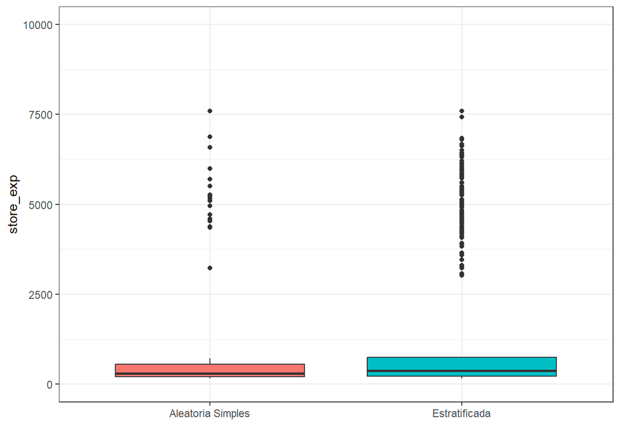

```r
amostra <- bind_rows(amostra1, amostra2)

amostra %>%
  ggplot() +
    geom_boxplot(aes(x = tipoAmostra, y = store_exp, fill = tipoAmostra)) +
      ylim(c(0, 10000)) +
      xlab(label = "") +
      theme_bw() +
      theme(legend.position = 'none')
```

Fazendo uma outra versão de gráfico onde é possível visualizar os tipos de amostragens e os segmentos.

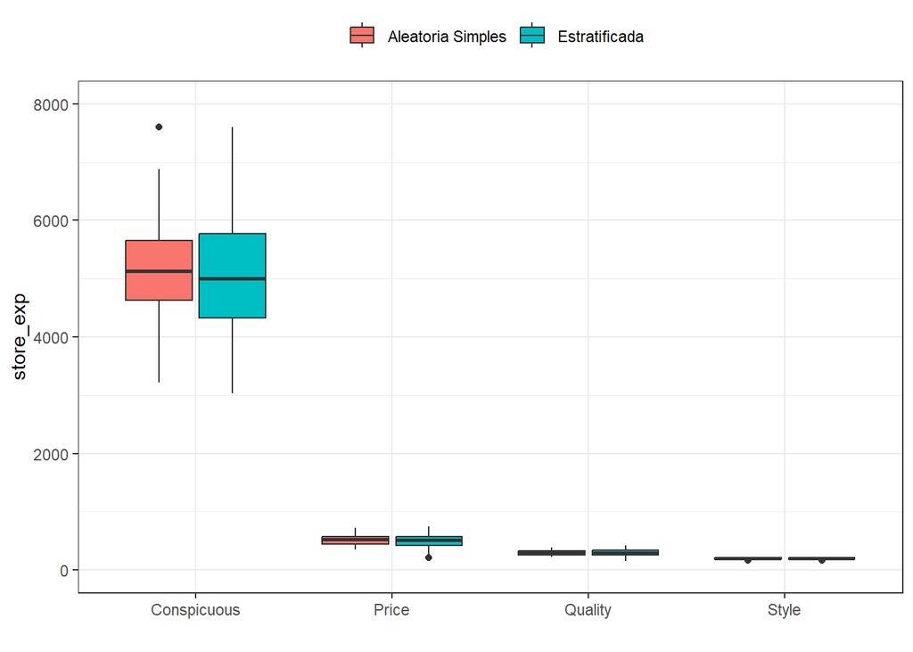

```r
amostra %>%
  ggplot() +
    geom_boxplot(aes(x = segment, y = store_exp, fill = tipoAmostra)) +
      ylim(c(0, 8000)) +
      xlab(label = "") +
      theme_bw() +
      theme(legend.position = 'top') +
      labs(fill = "")
```

Retirando o segmento *Conspicuous*, podemos visualizar melhor os demais segmentos.

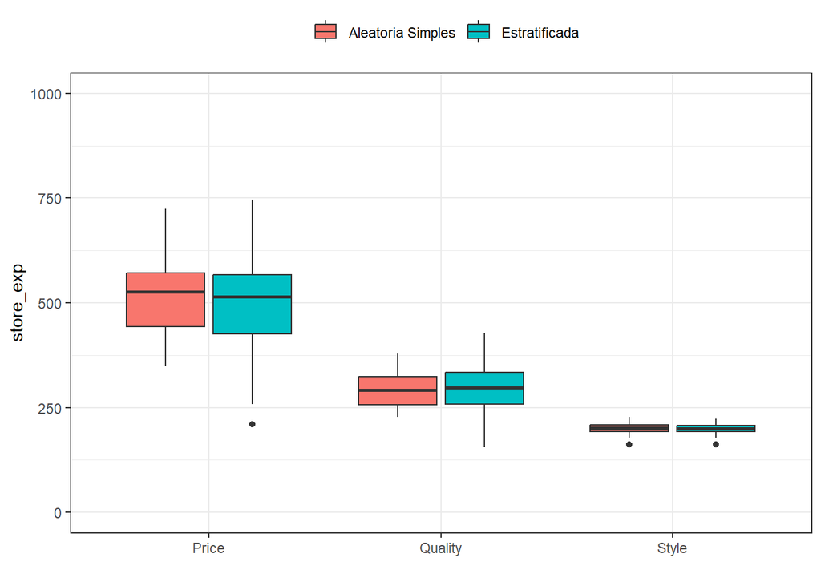

```r
amostra %>% filter(segment != "Conspicuous") %>%
  ggplot() +
    geom_boxplot(aes(x = segment, y = store_exp, fill = tipoAmostra)) +
      ylim(c(0, 1000)) +
      xlab(label = "") +
      theme_bw() +
      theme(legend.position = 'top') +
      labs(fill = "")
```

Note que em geral a variabilidade da variável em cada segmento é maior na amostra estratificada, o que faz sentido, pois garantimos representatividade em cada segmento.

## Teste de Hipótese

#### Cálculo do P-Valor

$$P-valor= 𝑃(\bar X<16 | \mu=18)= P(Z
< -1,826) = 0,033$$

```r
pnorm(-1.826)
```

```
## [1] 0.03392513
```

#### Teste de Normalidade

*Shapiro-Wilk*

```r
shapiro.test(sim.dat$age)
```

```
##
##  Shapiro-Wilk normality test
##
## data:  sim.dat$age
## W = 0.7544, p-value < 2.2e-16
```

*QQplot*

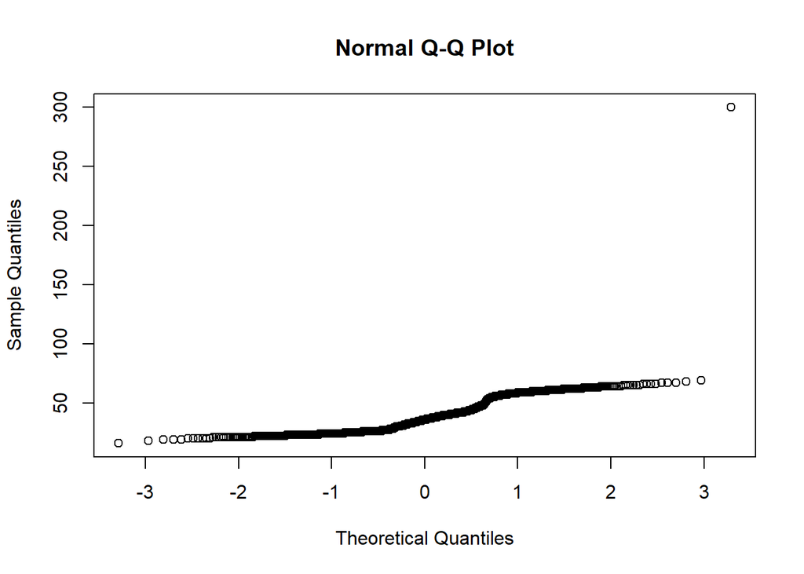

```r
qqnorm(sim.dat$age)
```

*Kolmogorov-Smirnov*

```r
ks.test(sim.dat$age,"pnorm",mean(sim.dat$age),sd(sim.dat$age))
```

```
##
##  Asymptotic one-sample Kolmogorov-Smirnov test
##
## data:  sim.dat$age
## D = 0.12759, p-value = 1.454e-14
## alternative hypothesis: two-sided
```

#### Comparação de grupos

*Teste t-student*

```r
AgeM <- sim.dat$age[sim.dat$gender == 'Male']
AgeF <- sim.dat$age[sim.dat$gender == 'Female']
```

```r
t.test(AgeM, AgeF)
```

```
##
##  Welch Two Sample t-test
##
## data:  AgeM and AgeF
## t = 7.7454, df = 829.66, p-value = 2.776e-14
## alternative hypothesis: true difference in means is not equal to 0
## 95 percent confidence interval:
##   6.014018 10.096779
## sample estimates:
## mean of x mean of y
##  43.30269  35.24729
```

*Teste de Mann-Whitney*

```r
wilcox.test(AgeM, AgeF)
```

```
##
##  Wilcoxon rank sum test with continuity correction
##
## data:  AgeM and AgeF
## W = 165701, p-value < 2.2e-16
## alternative hypothesis: true location shift is not equal to 0
```

#### Correlação de Pearson

```r
cor.test(sim.dat$store_exp, sim.dat$store_trans, method = "pearson", alternative = "two.sided")
```

```
##
##  Pearson's product-moment correlation
##
## data:  sim.dat$store_exp and sim.dat$store_trans
## t = 20.273, df = 998, p-value < 2.2e-16
## alternative hypothesis: true correlation is not equal to 0
## 95 percent confidence interval:
##  0.4946605 0.5825786
## sample estimates:
##       cor
## 0.5400914
```